# Lecture 2 — Energy generation

PHY199-RAP · Energy in the 21st Century

Dr. Salvatore Rappoccio

2026-08-31

**Material:** Lecture notes on [electricity and magnetism](https://en.wikipedia.org/wiki/Electromagnetism), nuclear fission and fusion, [Levelized Cost](https://en.wikipedia.org/wiki/Levelized_cost_of_electricity), [the grid](https://en.wikipedia.org/wiki/Electrical_grid). *Skill taught: note-taking.*

**Assignment:** [Academic Integrity at UB course on UBLearns](https://www.buffalo.edu/academic-integrity/resources/Academic-Integrity-at-UB.html), with quiz. Share badge on UBLearns.

# Skill of the week: note-taking

## The skill that makes every other class work

- This is a **UB Seminar** — we teach the *meta-skills*. First one up: **taking notes**
- Last week’s rule, restated: **process, don’t transcribe**
- The old “longhand beats laptops” study (Mueller & Oppenheimer, 2014) had a **weak replication** (Urry et al., 2021) — so it’s *not* pen-vs-laptop
- The real lesson: notes are for **thinking**, not stenography. If you’re just copying, you’ve turned your brain off
- **This will be relevant next week** — the Week 3 quiz is *on note-taking*

## The Cornell method: a note page that grades itself

- **1950s, Cornell:** Walter Pauk designed a page layout that forces processing
- Split the page: **narrow left column** (cues/questions), **wide right column** (notes in class), **strip along the bottom** (a 2-line summary you write *after*)
- The trick: cover the right side, and your left-column questions become a **self-quiz**
- It bakes in the two things that actually work (next slide): **retrieval** and **spacing**

## What the evidence says actually works

- Two techniques rate **high-utility** in the research: **practice testing** (quiz yourself) and **spacing** (spread study over days)
- **Rereading** and **highlighting** rate **low-utility** — they *feel* productive and mostly aren’t
- That’s *why* this course runs **low-stakes quizzes** — it’s retrieval practice, by design
- So take notes you can be **quizzed from**, then actually quiz yourself — don’t just admire your highlighter

## Worked example: notes on a 3-minute “lecture”

- Topic on the board: **“Should you wash rice before cooking?”** — a tiny, self-contained talk
- Watch a **Cornell page** fill in over the next few slides — we’ll build it live
- Your job *in the moment*: the **right column** — capture the ideas in shorthand, **don’t transcribe**
- The **left column** and the **summary** come *after* class — that’s where the actual learning happens

## In class — the RIGHT column (jot, don’t transcribe)

Raw notes as the talk runs — abbreviations, arrows, no full sentences:

- Wash rice? 2 reasons ppl give → (1) “less sticky” (2) “cleaner”
- Cloudy rinse water = **surface starch** washing off
- BUT stickiness ← **amylopectin** released *while cooking*, not surface starch
- → recent study: washing had **no effect** on stickiness/hardness; *variety* matters more

## In class — RIGHT column, continued

- So what *does* washing actually remove?
- **Debris**: dust, husk fragments, tiny stones — matters most where processing is less tidy
- **Microplastics**: ~**20%** off uncooked rice (~**40%** for instant rice)
- **Arsenic**: ~**90%** of *bio-accessible* arsenic (rice takes up more arsenic than most crops)
- **Tradeoff** ⚠ → washing / excess water also rinses out nutrients (Fe, Zn, Cu; enriched rice loses its vitamin coating)

## After class — the LEFT column (write the questions)

Cover the notes. For each chunk, write in the cue column the **question it answers**:

- *Does washing make rice less sticky?*
- *What actually causes stickiness?*
- *What does washing really remove?*
- *What’s the catch / tradeoff?*
- *Bottom line — wash or not?*

## After class — the SUMMARY strip (2 lines, your words)

> Washing rice clears surface starch, ~20% of microplastics, and ~90% of bio-accessible arsenic — but **not** stickiness (that’s amylopectin from cooking), and it also rinses out some nutrients. **Wash for cleanliness, not for fluffiness.**
- Write it from memory, in **your own words** — if you can’t, reread *once*, then try again
- One good summary now saves you rereading the whole page later

## The payoff: cover the notes, quiz yourself

Left column only — can you answer without peeking?

- *Does washing reduce stickiness?* → **No.** Stickiness is amylopectin released during cooking; washing only clears surface starch
- *What’s the tradeoff?* → Removes ~90% of bio-accessible arsenic **but** also strips iron/zinc + enriched vitamins
- Missed one? **That** is the bit to restudy — this is retrieval + spacing, exactly what the evidence rewards
- **Relevant next week:** the Week-3 quiz runs the same loop — cue → recall

## The finished Cornell page (all three zones)

**Cues / questions**

- Less sticky?
- Cause of stickiness?
- What’s removed?
- Tradeoff?
- Bottom line?

**Notes (in class)**

- Wash rice → claims: “less sticky” + “cleaner”
- Sticky ← amylopectin *from cooking*; washing ≠ less sticky
- Removes: debris; microplastics ~20% (~40% instant); arsenic ~90% bio-accessible
- ⚠ also removes Fe / Zn / Cu + enriched vitamins

**Summary:** Wash to remove grit and contaminants, not to change texture — and know you’re trading away some nutrients.

## Note-taking — sources

- [Mueller & Oppenheimer (2014), *Psychological Science*](https://journals.sagepub.com/doi/abs/10.1177/0956797614524581) · [Urry et al. (2021) — replication](https://journals.sagepub.com/doi/abs/10.1177/0956797620965541)
- [Dunlosky et al. (2013), *Psych. Science in the Public Interest*](https://journals.sagepub.com/doi/abs/10.1177/1529100612453266) · [accessible version, *American Educator*](https://www.aft.org/ae/fall2013/dunlosky)
- Cornell method: Pauk & Owens, *How to Study in College*; [Cornell Learning Strategies Center](https://lsc.cornell.edu/how-to-study/taking-notes/cornell-note-taking-system/)
- Worked example (washing rice): [The Conversation — “Do you need to wash rice? Here’s the science”](https://theconversation.com/do-you-need-to-wash-rice-before-cooking-heres-the-science-204692) · arsenic/nutrient tradeoff: [“Cooking rice in excess water reduces both arsenic and enriched vitamins…” (2016)](https://pubmed.ncbi.nlm.nih.gov/26515534/); [Menon et al. 2020, *Sci. Total Environ.*](https://www.sciencedirect.com/science/article/pii/S0048969720368728)

# Electricity and magnetism

## What is electricity, really?

- **Charge** is a property of matter (electrons carry it); pushing charge around is the whole game
- Three words you need:
  - **Voltage** (volts) — the *push* (like water pressure)
  - **Current** (amps) — the *flow rate* (like gallons per second)
  - **Power** (watts) — how fast energy is delivered: $P = V \times I$
- Your phone charger, Niagara Falls, and a nuclear plant differ only in **scale**

## 1820: Ørsted’s compass twitches

- Hans Christian **Ørsted** is lecturing when he notices a **compass needle deflect** next to a wire carrying current
- Bombshell: **electricity and magnetism are the same thing**, wearing two hats
- A **current makes a magnetic field**. Hold that thought — the reverse is where the power comes from

[figure not shown]

Hans Christian Ørsted (1777–1851). Portrait by C. W. Eckersberg, public domain.

## 1831: Faraday runs it backwards

- Michael **Faraday** shows the reverse: a **changing magnetic field pushes a current** through a nearby wire
- **Faraday’s law of induction** — the single most important sentence in this whole course:
  $$\mathcal{E} = -\frac{d\Phi_B}{dt}$$
- In English: **move a magnet past a coil of wire, and you make electricity.** No fuel required to state the principle — only to *move the magnet*

[figure not shown]

Michael Faraday (1791–1867). Portrait by Thomas Phillips, 1842, public domain.

## Every power plant is the same machine

- Coal, gas, nuclear, hydro, geothermal, wind — all do **one thing**: spin a magnet inside coils of wire (a **turbine + generator**)
- The *only* difference is **what spins the turbine**: steam, falling water, or wind
- **Solar photovoltaic is the lone exception** — it makes current *directly*, no moving parts (we met this in Lecture 1)
- **Callback:** Niagara’s **Adams Plant (1895)** — the first big AC power — was this exact machine, driven by falling water

## 1865: Maxwell writes the whole thing down

- James Clerk **Maxwell** unifies electricity, magnetism, and **light** into four equations
- His shocker: light *is* an electromagnetic wave — radio, microwaves, X-rays, and visible light are the **same phenomenon** at different frequencies
- Why you care: this is the physics behind **the grid** (AC at 60 Hz), **wireless charging**, and every screen you own

## Electricity & magnetism — sources

- Foundations: [Britannica — Electromagnetism](https://www.britannica.com/science/electromagnetism); [HyperPhysics (Georgia State) — E&M](http://hyperphysics.phy-astr.gsu.edu/hbase/emcon.html)
- Ørsted/Ampère (1820): [Britannica — Hans Christian Ørsted](https://www.britannica.com/biography/Hans-Christian-Orsted)
- Faraday (1831–32): [Royal Society commentary on Faraday’s *Experimental Researches*](https://royalsocietypublishing.org/doi/10.1098/rsta.2014.0208); [Britannica — Faraday’s law](https://www.britannica.com/science/Faradays-law-of-induction)
- Maxwell (1865): [Britannica — Maxwell’s equations](https://www.britannica.com/science/Maxwells-equations)
- Generators: DOE energy.gov (corroborate w/ Britannica per source rule)

# Nuclear: fission and fusion

## $E = mc^2$: mass is frozen energy

- Einstein (1905): **mass and energy are the same thing.** A tiny bit of mass holds a *staggering* amount of energy
- The multiplier is $c^2$ — the speed of light, squared — which is enormous
- **Fully** converting **1 gram** of *anything* would release **≈ 25 GWh** — roughly a **small city’s electricity for a day**
- Nature won’t let you convert it all — but nuclear reactions unlock **far more** of it than chemistry (burning) ever can

## Why iron sits at the bottom of the valley

- Every nucleus has a **binding energy** — how tightly its protons and neutrons are glued
- Plot it and you get a **valley** with **iron-56** at the bottom (most tightly bound, most stable)
- **Two ways downhill = two ways to release energy:**
  - **Fission:** split a *heavy* nucleus (uranium) → move toward iron → energy out
  - **Fusion:** join *light* nuclei (hydrogen) → move toward iron → energy out
- Everything from here is just: *roll downhill toward iron*

[figure not shown]

Nuclear binding energy per nucleon vs. mass number — iron-56 sits at the peak; fusion (light nuclei) and fission (heavy nuclei) both release energy by moving toward it. Fastfission, public domain.

## Fission: splitting the heavy stuff

- **1938:** Hahn, Strassmann, **Lise Meitner** and Frisch discover **nuclear fission** — a uranium nucleus split by a neutron
- Each split throws out **more neutrons** → they split more nuclei → a **chain reaction**
- Controlled slowly in a **reactor** (steam → turbine → the same machine as before). Uncontrolled, it’s a **bomb** — the dark side we cover in Weeks 5–6
- Meitner did the theory and was **snubbed by the Nobel** — a name worth knowing

[figure not shown]

A fission chain reaction: a neutron splits a nucleus into fragments plus more neutrons, which split more. Diagram by MikeRun, CC BY-SA 4.0.

## A gram of uranium (the simple calculation)

- Fissioning **1 gram of uranium-235** releases **≈ 23 MWh** of energy
- That single gram equals about **3 tonnes of coal** (a wheelbarrow of rock vs. a fingernail’s worth of metal)
- Fission of **1 kg** ≈ **22.8 GWh** ≈ enough for **~2,000 US homes for a year**
- The catch isn’t the physics — it’s the **waste, the mining, and the weapons** (Weeks 5–6)

| Fuel | Energy from 1 gram | Equivalent |
| --- | --- | --- |
| Coal | ~0.007 kWh | — |
| Uranium-235 (fission) | **~23,000 kWh** | ~3 tonnes of coal |
| Any mass (full $E=mc^2$) | ~25,000,000 kWh | the theoretical ceiling |

## Fusion: the Sun’s furnace

- **Fusion** joins light nuclei (hydrogen → helium) and powers **every star**, including the **Sun**
- It’s the cleanest energy imaginable: fuel from **water**, no long-lived waste, no meltdown, no CO₂
- The deuterium in **1 liter of water** holds fusion energy comparable to **~300 liters of gasoline**
- One catch: it needs **~100 million °C**. The Sun cheats with crushing gravity; we don’t have that

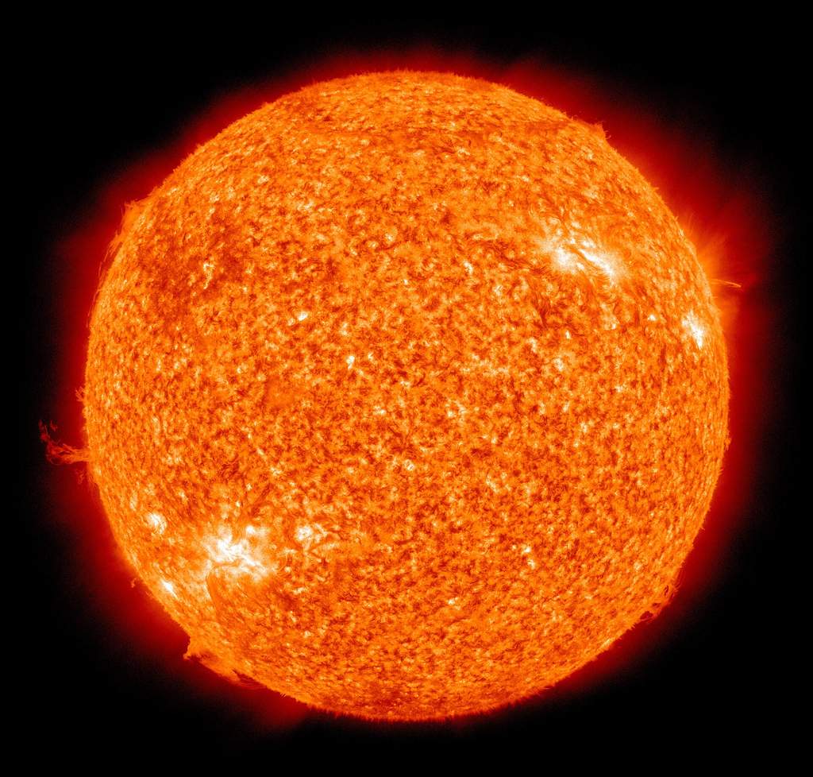

The Sun in ultraviolet light — the churning surface of our nearest fusion reactor. NASA/SDO (AIA), public domain. *(Federal image — corroborate with an independent solar-observatory source per the course source rule.)*

## 2022–2039: fusion’s real, slow timeline

- **Dec 2022, Livermore (NIF):** for the first time, a fusion shot released **more energy than the lasers delivered to the fuel** — scientific “ignition,” peer-reviewed and independently repeated
- **ITER** (France, a 35-nation project) is the big test reactor — but it just **slipped a decade**: **first plasma now ~2034**, full deuterium–tritium burn **~2039**, at **billions over budget**
- Honest verdict: fusion is **real physics and still decades from your wall socket.** Don’t let anyone sell you “five years away”

## Nuclear — sources

- $E=mc^2$: [Einstein (1905), *Annalen der Physik*](https://onlinelibrary.wiley.com/doi/10.1002/andp.19053231314) (English trans. widely available)
- Fission discovery: [Meitner & Frisch (1939), *Nature*](https://www.nature.com/articles/143239a0); [Britannica — nuclear fission](https://www.britannica.com/science/nuclear-fission)
- Binding energy / data: [IAEA Nuclear Data Services](https://www-nds.iaea.org/); Krane, *Introductory Nuclear Physics*
- Fusion basics: [ITER Organization — What is fusion?](https://www.iter.org/sci/whatisfusion); [Britannica — nuclear fusion](https://www.britannica.com/science/nuclear-fusion)
- NIF ignition: [Abu-Shawareb et al. (2024), *Phys. Rev. Lett.*](https://link.aps.org/doi/10.1103/PhysRevLett.132.065102)
- ITER delay: [Physics World — ITER hit by decade-long delay](https://physicsworld.com/a/iter-fusion-reactor-hit-by-massive-decade-long-delay-and-e5bn-price-hike/)

# What does it cost? Levelized Cost of Electricity

## LCOE: the only fair way to compare

- You can’t compare a solar farm and a gas plant by sticker price — they last different years and run different hours
- **Levelized Cost of Electricity (LCOE)** puts everything on **one number: dollars per unit of energy**
  $$\text{LCOE} = \frac{\text{lifetime costs (build + fuel + upkeep)}}{\text{lifetime energy produced}}$$
- Think **$/MWh** (or ¢/kWh). It’s the “**price per mile**” of a power plant — the honest apples-to-apples

## Lazard 2025: what’s actually cheapest (unsubsidized)

| Source | LCOE ($/MWh) | Notes |
| --- | --- | --- |
| **Onshore wind** | **37 – 86** | cheapest new build |
| **Utility solar** | **38 – 217** | also cheapest at the low end |
| Combined-cycle gas | 48 – 109 | the fossil workhorse |
| Coal | 71 – 173 | dirty *and* not cheap |
| Battery storage (2-hr) | 81 – 174 | the intermittency patch |
| Nuclear | 141 – 220 | safe, low-carbon, **expensive to build** |
| Gas peaker | 149 – 251 | only for demand spikes |

- **New wind and solar are the cheapest electricity humans have ever built** — even before subsidies

*Source: Lazard, LCOE+ (June 2025), unsubsidized ranges.*

## What LCOE quietly leaves out

- **Intermittency:** the sun sets and the wind drops. A cheap solar MWh at noon isn’t a cheap MWh at 9 pm — you need **storage or backup** (that’s the battery row)
- **Grid/firming costs:** Lazard’s own numbers **exclude** the wires and balancing needed to make power *dependable*
- **Externalities:** LCOE ignores the **death cost** and **carbon cost** we met in Lecture 1 — coal’s cheap $/MWh doesn’t include the **people it kills**
- **Takeaway:** LCOE is the best *starting* number and a **terrible ending** one. Cheapest on the spreadsheet ≠ cheapest in full

## LCOE — sources

- Method: [NREL — Levelized Cost of Energy](https://www.nrel.gov/analysis/tech-lcoe.html); [NREL Annual Technology Baseline](https://atb.nrel.gov/)
- 2025 figures: [Lazard — LCOE+ (June 2025)](https://www.lazard.com/research-insights/levelized-cost-of-energyplus-lcoeplus/); [Lazard 2025 press release](https://www.lazard.com/news-announcements/lazard-releases-2025-levelized-cost-of-energyplus-report-pr/)
- Independent write-ups: [pv magazine — solar/wind still cheapest](https://pv-magazine-usa.com/2025/06/17/despite-low-gas-prices-solar-wind-remain-cheapest-sources-of-power-in-u-s/); [RTO Insider](https://www.rtoinsider.com/108308-lazard-solar-wind-retain-lowest-lcoes/)
- Externalities (callback): [Our World in Data — deaths per TWh](https://ourworldindata.org/grapher/death-rates-from-energy-production-per-twh); [IPCC AR6 Synthesis](https://www.ipcc.ch/report/ar6/syr/)

# The grid: getting it to your wall

## From the plant to your phone charger

- Electricity is made in a few big places and used in **millions** of small ones. The **grid** is the machinery in between
- Three stages: **generation** (the plant) → **transmission** (the tall steel towers, very high voltage) → **distribution** (the wooden poles on your street, stepped back down)
- It is arguably the **largest machine ever built** — a continent wired into one synchronized system

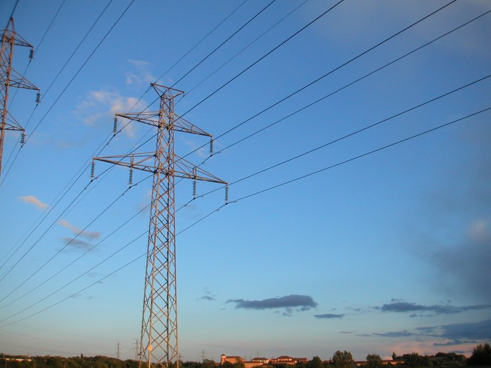

High-voltage transmission towers — the grid moves power at high voltage to cut resistive losses. Photo by Nixdorf, CC BY-SA 3.0.

## Why the towers run at insane voltage

- Push current through a wire and some power is **lost as heat** — losses scale with **current squared** ($P_{\text{loss}} = I^2 R$)
- Trick: send the *same power* at **high voltage and low current** → far less loss. Then **step it back down** near you
- The device that does this — the **transformer** — **only works with AC**
- **Callback:** *this* is why **AC beat DC** in Lecture 1’s Current Wars. Edison’s DC couldn’t do this cheaply; Tesla/Westinghouse’s AC could

## The grid is a tightrope walk — every second

- You **can’t store much electricity in the grid** — supply must match demand **instant to instant**
- The proof is the **frequency**: North America runs at **60 Hz**, and it must stay there. Too much demand → it sags; too much supply → it climbs
- Grid operators (here, the **NYISO**) rebalance **second by second**, all day, forever
- Lose the balance and the system **protects itself by shutting down** — which is how a small fault becomes a **blackout**

## Aug 14, 2003: the day the Northeast went dark

- It started small: an **Ohio utility’s software failed** and some **overgrown trees** touched power lines near Cleveland
- With operators flying blind, the imbalance **cascaded across the grid in minutes**
- **~50 million people** across **eight US states and Ontario** lost power — including **right here in Buffalo and Western New York**
- One overgrown tree + one software bug → a subcontinent dark. **That’s how tightly coupled the grid is**

## Keeping the lights on (and the hard part ahead)

- The grid is always juggling: **baseload** (steady — nuclear, some gas), **peakers** (fast spikes), and increasingly **wind, solar, and batteries**
- Renewables are the **cheapest** energy (LCOE) but **variable** — so the 21st-century grid problem is **timing and storage**, not generation cost
- **Batteries, long-distance transmission, and demand shifting** are how we square cheap-but-intermittent with a grid that must balance every second
- **Relevant later (Week 7):** all those **AI data centers** are enormous new demand landing on this same tightrope

## The grid — sources

- Grid basics: [Britannica — electric power system](https://www.britannica.com/technology/electric-power); [HyperPhysics — transformers & transmission](http://hyperphysics.phy-astr.gsu.edu/hbase/magnetic/transf.html)
- Operations / frequency: [NYISO — how the grid works](https://www.nyiso.com/how-the-grid-works); NERC frequency standards
- 2003 blackout: [U.S.–Canada Power System Outage Task Force Final Report](https://www.energy.gov/oe/articles/blackout-2003-us-canada-task-force-presents-final-report-onblackout-august-2003) *(federal — corroborate)*; [Scientific American — five years later](https://www.scientificamerican.com/article/2003-blackout-five-years-later/)
- Storage/future grid: [IEA — Electricity Grids and Secure Energy Transitions](https://www.iea.org/reports/electricity-grids-and-secure-energy-transitions)

# How this deck was built

## AI-use disclosure (per our own policy)

- **Model / company:** Claude (Anthropic)
- **What it drew from:** the **primary sources on every Sources slide** — I verified each one and did the physics/finance myself
- **Where:** Anthropic compute runs on major U.S. cloud regions *(exact region confirmed at build)*
- **Compute / tokens:** **≈ 0.9 million tokens** (estimate) to research, calculate, and draft this quarry
- **Energy / water (order-of-magnitude):** **≈ 0.15–0.4 kWh** and **≈ 0.05–0.8 L** — a range on purpose; providers report differently
- The human (me) checked every number and source. **That’s the standard I’ll hold you to in your final project.**

## Takeaway: one machine, one ledger, one tightrope

- **The physics:** almost all electricity is one trick — *change a magnetic field, make a current* (Faraday). Nuclear just unlocks more of $E=mc^2$
- **The cost:** LCOE makes wind and solar the cheapest ever — but the number hides intermittency and the human/climate bill
- **The delivery:** the grid must balance every second; cheap-but-variable power makes that the century’s real challenge
- **Skill:** take notes you can be **quizzed from** — then quiz yourself

# Watch this week (optional)

## Physics on your feed: fields & Maxwell

- **[3Blue1Brown](https://www.youtube.com/watch?v=rB83DpBJQsE)** — *“Divergence and curl: the language of Maxwell’s equations.”* The best visual intuition for the E&M we did today (Grant Sanderson; **vetted**)
- **[Elle Cordova](https://www.youtube.com/@ElleCordova)** — her *“Fundamental Forces of Physics”* bits personify **electromagnetism** as a character. Funny, and it sticks (**vetted**)
- **[learnwithsherlock](https://www.instagram.com/learnwithsherlock/)** — short, clean physics explainers, incl. electromagnetism (**vetted**; IG/TikTok)

## The atom: fission, fusion, and CERN

- **[Dr. Clara Nellist — @particleclara](https://www.instagram.com/particleclara/)** — real CERN particle physicist doing first-year-friendly explainers. **She’s a friend of mine** — lean in (**vetted**; IG/TikTok/[YouTube](https://www.youtube.com/@ParticleClara))
- **[CERN](https://home.cern/)** (official, **vetted**) — the source for “what a lab actually does.” *Reminder: I work on **CMS**, one of the big LHC experiments — ask me anything*
- **Brian Cox** — *“Can We Make a Star on Earth?”* (BBC) on **fusion** and how stars burn. A trusted traditional communicator (**vetted**) — *I’ve worked with him*
- **[Kurzgesagt — “Fusion Power Explained: Future or Failure”](https://www.youtube.com/watch?v=mZsaaturR6E)** *(secondary)* — great animation; pairs with our “real, but decades away” verdict

## The grid: how electricity *actually* travels

- **[Veritasium — “The Big Misconception About Electricity”](https://www.youtube.com/watch?v=bHIhgxav9LY)** *(secondary)* — energy rides in the **fields around** the wires, not “through” them. A mind-bending pairing with our transmission/grid slides
- Follow-up (*same channel, secondary*): *“How Electricity Actually Works”* answers the pushback on the first video
- **Honest gap:** our **vetted** list is a physics/AI/math roster — it doesn’t yet cover **LCOE / energy economics** or **note-taking**. If you find a good creator for those, add them to the trusted list

# Cast a wider net: creators to vet

## Energy economics & LCOE (filling the gap)

- **[Engineering with Rosie](https://www.youtube.com/watch?v=i-891blV02c)** — engineer Rosemary Barnes; her video *“Does LCOE give us the right numbers?”* is a near-perfect match for today’s cost section
- **[Our World in Data](https://ourworldindata.org/energy)** — the data source behind our LCOE/deaths-per-TWh figures; charts you can actually cite
- **[Volts — David Roberts](https://www.volts.wtf/)** — deep energy-economics & policy (podcast/newsletter; more advanced)
- **[Just Have a Think](https://www.youtube.com/@JustHaveaThink)** & **[Undecided w/ Matt Ferrell](https://www.youtube.com/@UndecidedTechnology)** — energy-transition explainers with sources
- **[Ziroth](https://www.youtube.com/c/ZirothTech)** — clean energy-data visualizations

*None vetted yet — candidates for the trusted list. They point where the cost and climate data point; vet each for rigor and primary sourcing, and watch for hype (over-optimistic timelines), not for “balance.”*

## Grids, reactors & how things really work

- **[Practical Engineering — Grady Hillhouse](https://practical.engineering/blog/2019/6/24/how-does-the-power-grid-work)** — the gold standard on **the grid**: transmission, transformers, balancing, blackouts
- **[Illinois EnergyProf — Prof. David Ruzic](https://www.youtube.com/@illinoisenergyprof6878)** — an actual nuclear/plasma professor on **fission & fusion**; energetic and rigorous
- **[Real Engineering](https://www.youtube.com/@RealEngineering)** — well-produced deep dives (e.g., *“The Problem with Nuclear Fusion”*)
- **[Steve Mould](https://www.youtube.com/@SteveMould)** — hands-on **electromagnetism/induction** demos you can almost feel

## Study skills: note-taking

- **[Justin Sung](https://www.youtube.com/@JustinSung)** — former doctor turned learning-science coach; evidence-based note-taking (mapping over transcribing) that lines up with today’s skill
- **[Benjamin Keep](https://www.youtube.com/@BenjaminKeep)** — learning-science explainers on retrieval, spacing, and note strategies
- Ties directly to our Cornell-method / “process, don’t transcribe” slides — good optional follow-up for the Week-3 note-taking quiz

*Non-vetted — review before recommending; both cite the cognitive-science literature.*